# Tutorial: COVID Vaccine Efficacy

In this notebook, we will take a thematic digression into an example from the world of medicine. While the particular model we look at here isn't likely to be one you encounter in astrophysics, it has some neat features that make it useful for practicing our methodology. Compared to previous tutorials, you will be much more on your own to implement the inference. We won't prescribe a specific algorithm or package for you to use. Exactly how to carry out the fits is up to you, although you are expected to follow best practices (testing convergence, etc.).

Specifically, you will

- define a generative model for the scenario described;
- constrain the model posterior;
- compute posterior quantities of interest, including credible intervals;
- repeat this for a second data set that provides less information, modifying the model as required.

```python
# !pip install incredible pygtc

import numpy as np
import scipy.stats as st
import matplotlib.pyplot as plt
%matplotlib inline

import incredible as cr
from pygtc import plotGTC

# here are some packages you may want to use (pip install if needed)
#import dynesty
#import emcee
#import lmc
#import pymc
```

```python
# do not mess with the housekeeping
# Tests housekeeping
```

## Background

Among other things, the years 2020-2021 are notable for the number of people taking an close interest in the process of vaccine development and approval who ordinarily wouldn't. It came as a great relief to many when, in the autumn of 2020, pharmaceutical company Pfizer announced that they had developed a vaccine for Covid-19 that was safe and 95% effective.

The level of detail in [this New York Times article](https://www.nytimes.com/2020/11/18/health/pfizer-covid-vaccine.html) is representative of reporting on both the Pfizer announcement and the later Moderna announcement. (The information publically released by AstraZeneca about their trials at the time, at least that I could find, was not sufficient to perform a similar analysis to the one we do below.)

> Pfizer and BioNTech’s trial included nearly 44,000 volunteers, half of whom received the vaccine. The other half received a placebo shot of salt water. Then the researchers waited to see how many in each group developed Covid-19.

> The companies said that out of 170 cases of Covid-19, 162 were in the placebo group, and eight were in the vaccine group.

[output not shown]

For those of a certain mindset, the reporting immediately raised three questions:

1. What *exactly* does effectiveness mean in this context?
2. What is the uncertainty on the 95%? (You might intuitively suspect it's large, given the small fraction of participants who tested positive at all.)
3. Is it possible to answer these questions based only on the mass-media reports (i.e. without waiting for more official documentation)?

As to the first question above, we will use the following generative model, including a definition of effectiveness, which I claim is logical and which ends up yielding a best-fit effectiveness of 95%:

- Trial participants are split into control and treatment groups with sizes $N_\mathrm{c,tot}$ and $N_\mathrm{t,tot}$. We don't know precisely what these values are, but will probably be ok assuming that they are both 22,000.
- Let $P_\mathrm{exp}$ be the average probability that one of the control participants is exposed to Covid-19 *and* becomes infected *and* is tested for Covid-19 (surveillance testing not being widely available at this point in time) *and* tests positive. $N_\mathrm{c,pos}$ of them do so.
- We will assume that the control and treatment groups are similar enough that this average probability would also apply to members of the treatment group *if they had not been vaccinated*. That is, it is the probability that they are sufficiently exposed to Covid-19 that they would have become ill and tested positive had they not been vaccinated. There is a corresponding, unknown number of treatment-arm participants, $N_\mathrm{t,exp}$, who have this level of exposure but do not *necessarily* become ill, get tested and/or test positive, due to vaccination.
- For the members of the treatment group with this level of exposure, the probability that they do *not* go on to become ill and test positive is $P_\mathrm{vac}$. This is the "effectiveness", essentially the fractional reduction in the number of particpants who test positive, comparing the control and treatment groups. Conversely, these highly exposued treatment-group participants have a probability $1-P_\mathrm{vac}$ of testing positive despite vaccination. The number that do is $N_\mathrm{t,pos}$.

(To be clear, I am not claiming that either the company or the FDA plugged this model through a Bayesian analysis like we will. Almost certainly they didn't, although I suspect the method they did use is an approximation to what we will do, since the results are so similar.)

Answering the second and third questions is, of course, the point of the remainder of this notebook.

## Specify the model and priors

The bullet-point model above is a bit convoluted. Naturally, your first job is to map out this model as a PGM and fully specify it in generative form. To help, here are the quantities mentioned above that are explicitly given in the article:

- $N_\mathrm{c,tot}$: total number in control arm
- $N_\mathrm{t,tot}$: total number in treatment arm
- $N_\mathrm{c,pos}$: number of positive cases in control arm
- $N_\mathrm{t,pos}$: number of positive cases in treatment arm

```python
data = {'Nc_pos': 162,
        'Nc_tot': 22000,
        'Nt_pos': 8,
        'Nt_tot': 22000}
```

In addition to these quantities, we will have to account for

- $P_\mathrm{exp}$: probability of exposure/vulnerability resulting in positivity WITHOUT treatment
- $N_\mathrm{t,exp}$: number in the treatment branch equivalently exposed/vulnerable
- $P_\mathrm{vac}$: probability of one of those treatment-branch patients NOT testing positive

which are not given. These are either parameters of interest or things we need to marginalize over, depending on your point of view. For the sake of organization, let's define the following canonical order for these parameters:

```python
param_names = ['Pexp', 'Nt_exp', 'Pvac']
param_labels = [r'$P_\mathrm{exp}$', r'$N_\mathrm{t,exp}$', r'$P_\mathrm{vac}$']
```

Finally, you will need to define priors for $P_\mathrm{exp}$ and $P_\mathrm{vac}$. As usual, we will discuss these in class. Spell out your complete generative model below:

> Space for PGM and generative model

Below, make a figure visualizing the priors on these 2 parameters.

```python
# YOUR CODE HERE
raise NotImplementedError()
```

```
We'll leave you guessing about the priors we chose.
```

```python
# Checkpoint priors_look_byI 0
# Nothing in here; plots should be above
# End checkpoint
```

## Inference for Pfizer/BioNTech

You are now on your own to sample the posterior of the above model. We will not prescribe a specific method or package, but for uniformity of grading there are a few requirements.

#### Requirements:

- Produce equally weighted samples from the posterior and store them (after removing any burn-in and doing any thinning you feel necessary) in `chains1` in the form of multiple (**at least 4**) chains, as either a list of $N_\mathrm{samples} \times N_\mathrm{params}$ arrays, or a single $N_\mathrm{chains} \times N_\mathrm{samples} \times N_\mathrm{params}$ array (i.e., in one of the formats that `incredible` understands). This doesn't mean you necessarily have to use an MCMC method, but if you use some other method you must be able to extract results in the above format (even if it means artificially breaking samples into multiple "chains"). There will be cells below for plotting traces, and tests for convergence and a minimum number of effectively independent samples, that will assume this format, and that must be passed. Parameters should be ordered as in `param_names`.
- "Approximate Methods" methods are not allowed. We want the real posterior.
- **Explain your work** with the kind of verbosity you're accustomed to seeing in these notebooks. Leave in any work that was part of your process (e.g., performing an initial optimization, plotting traces before removing burn-in), even if they aren't strictly necessary for the final product.

An unusual feature of this problem, for us, is that one of the parameters can only take on integer values. This may impact the approach you decide to use, and is certainly worth a little thought. We will be testing that your chain entries for $N_\mathrm{t,exp}$ are indeed non-negative integers.

You can use and/or add as many cells as needed below. We will do a similar inference in the next section, so we suggest you organize your code to make it as straightforward as possible to modify.

```python
# YOUR CODE HERE
raise NotImplementedError()
```

```
CPU times: user 3.29 s, sys: 343 ms, total: 3.64 s
```

```
Wall time: 3.33 s
```

### Testing the fit

Welcome back! We will now look at standard diagnostics of the chains you stored in `chains1`. First, traces.

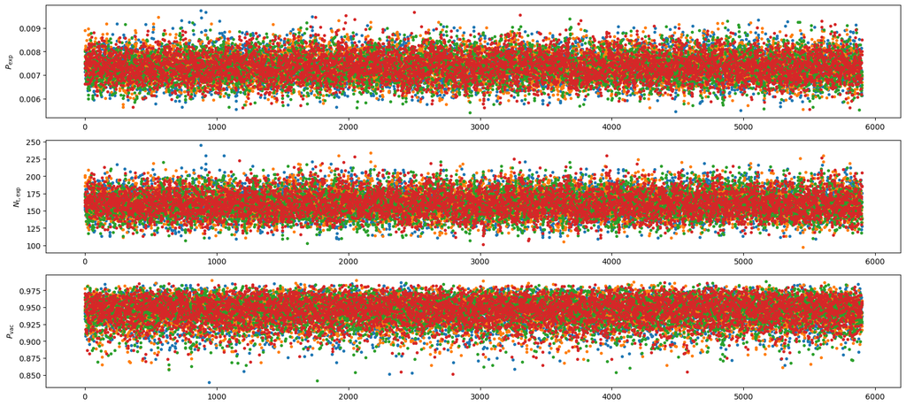

```python
# Checkpoint traces1_byI 0
fig, ax = plt.subplots(len(param_names), 1, figsize=(20, len(param_names)*3));
if chains1.__class__ == list:
    cr.plot_traces(chains1[:min(8,len(chains1))], ax, labels=param_labels);
else:
    cr.plot_traces(chains1[:min(8,chains1.shape[0]),:,:], ax, labels=param_labels);
# End checkpoint
```

Next the Gelman-Rubin convergence criterion and effective number of samples. Adjust the value of `maxlag` below if needed. Note that the test thresholds below are somewhat arbitrary, but fine for practice.

```python
maxlag = 1000 # you might need to change this
```

```python
# Checkpoint converge1 1
R = cr.GelmanRubinR(chains1)
print("R =", R)
assert np.all(R < 1.05)
neff = cr.effective_samples(chains1, maxlag=maxlag, throw=True)
print("neff =", neff)
assert np.all(neff > 500)
# End checkpoint
```

```
R = [1.00035783 1.00034845 0.99994272]
neff = [ 7855.69272892  7405.60219999 16745.80700528]
```

Assuming these tests were passed, we'll combine the chains and look at a triangle.

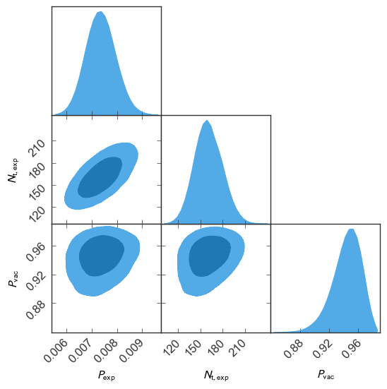

```python
# Checkpoint triangle1_byI 0
chain1 = np.concatenate(chains1, axis=0)
plotGTC(chain1, paramNames=param_labels, figureSize=6, customLabelFont={'size':12}, customTickFont={'size':12});
# End checkpoint
```

Let's also make sure that $N_\mathrm{t,exp}$ is integer valued. (This obviously makes the way its posterior is shown in the triangle above a little strange, but given the size of the constraint this is fine for visualization. If we cared about getting a credible interval for it, we'd want to be careful rather than using functions that assume real-valued parameters.)

```python
# Checkpoint integer_test1 1
assert np.all(chain1[:,1] == np.round(chain1[:,1]))
# End checkpoint
```

### Summarize results

Let's finish this section with some important calculations:

1. the posterior mode for $P_\mathrm{vac}$,
2. the 95% (note well: 95.000%, for comparison to the published result) highest-posterior-density credible interval for $P_\mathrm{vac}$, and
3. the posterior probability that $P_\mathrm{vac} > 0.6$, the threshold for a vaccine to be considered "effective" enough for widespread adoption under the circumstances, if I remember.

As above, show and explain your work, and save the results in the corresponding variables named below.

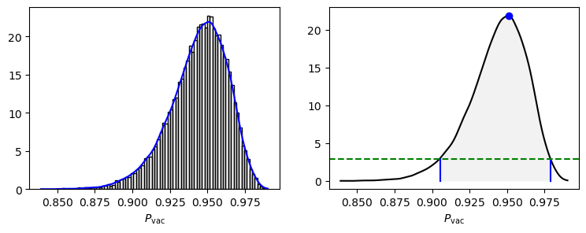

```python
# Pvac _mode = ...
# Pvac_min = ... # lower bound of the credible interval
# Pvac_max = ... # lower bound of the credible interval
# P_gt_60 = ... # probability that Pvac > 60%
# All as scalars, please

# YOUR CODE HERE
raise NotImplementedError()
```

```python
print(Pvac_mode, Pvac_min, Pvac_max, P_gt_60)
```

```
0.9509026178039064 0.905330772421279 0.9787191987517438 1.0
```

You should find something quite similar to the published interval of 90.3 - 97.6%.

```python
# here we will check various aspects of your results
# Tests post_test1 (1 point)
```

## Application to AstraZeneca/Oxford

Let's see how a similar analysis might be applied to the information publicly available about a competing vaccine from AstraZeneca and Oxford, released at around the same time. (If you're curious about the case of the Moderna vaccine, see here.)

The publicly released information in this case is less complete, as [this article](https://www.biopharmadive.com/news/astrazeneca-oxford-coronavirus-vaccine-efficacy-results/589542/) typifies.

> An experimental coronavirus vaccine developed by AstraZeneca and the University of Oxford protected against COVID-19 in two late-stage, placebo-controlled trials of roughly 23,000 participants in the U.K. and Brazil, the development partners said Monday.

> An interim analysis after 131 volunteers developed COVID-19 found that, on average, vaccination was 70% effective in preventing the disease. A lower-dose regimen, with a half-dose given first followed by a full dose one month later, was 90% effective, while two full doses appeared 62% effective.

> AstraZeneca said that about 2,741 people received a half dose of the vaccine followed by a full dose, while a total of 8,895 people received the two full doses.

> In addition, none of the volunteers in the low-dose group were over 55 years old.

> AstraZeneca and Oxford's results come from a "pooled" analysis of data from two studies: the COV002 trial, which enrolled 12,390 volunteers in the U.K., and the COV003 study of 10,300 participants in Brazil. The 90% efficacy figure cited by the companies is based on data from a smaller group of 2,741 volunteers who received the lower-dose regimen, while the 62% number is from 8,895 participants who were given the higher-dose regimen.

> AstraZeneca and Oxford did not share how they averaged the numbers nor how many cases of COVID-19 were observed in either group.

In short, this is a mess. Too little information is provided for us to replicate the results. However, we can get somewhere if we bundle the two treatments described togther (ignoring the potential systematic difference in vulnerability between the groups receiving them), and also bring in prior information about the general prevalence of COVID.

To be explicit, the data we are given in this case comprise

- $N_\mathrm{t,tot}$: total number in treatment arm (2741+8895)
- $N_\mathrm{c,tot}$: total number in control arm (let's take this to be the total number enrolled minus the above)
- $N_\mathrm{pos}$: number of positive cases across the board

```python
data = {'Nt_tot': 11636,
        'Nc_tot': 11054,
        'N_pos':  131}
```

A significant difference from our first case is that we are not told how many positive cases occured in the control branch and how many in the treatment branch, only how many overall. Consequently, we will have an additional nuisance parameter to marginalize over. For concreteness, let's take the formerly given $N_\mathrm{c,pos}$ to be a free parameter, and incorporate the information from $N_\mathrm{pos}$ through the deterministic relation $N_\mathrm{t,pos} = N_\mathrm{pos} - N_\mathrm{c,pos}$.

```python
param_names = ['Pexp', 'Nt_exp', 'Pvac', 'Nc_pos']
param_labels = [r'$P_\mathrm{exp}$', r'$N_\mathrm{t,exp}$', r'$P_\mathrm{vac}$', r'$N_\mathrm{c,pos}$']
```

If you're wondering how 4 parameters can be constrained from 3 data entries, the answer is that they can't. If you try to constrain this model with "uninformed" priors (do try it!), you'll find that $P_\mathrm{vac}$ is consistent with all values between 0 and 1. Out of our list of parameters, $P_\mathrm{exp}$ is the most reasonable one for us to claim prior knowledge of, given that in principle it has nothing to do with the particular treatment being tested. While the actual group being studied in different trials may be differently vulnerable, making $P_\mathrm{exp}$ potentially trial-specific, this is at least a place to start.

Therefore, let's use the $N_\mathrm{c,pos}$ and $N_\mathrm{c,tot}$ values from the previous section (nothing related to the treatment arm!) to define a prior on $P_\mathrm{exp}$ to use here, possibly incorporating some extra uncertainty to account for the different population. As usual, the details will be agreed on in class.

With all that done, update your PGM etc. for this section.

> Space for PGM etc.

Now perform the inference for this model and data set. All the same requirements apply as in the last section. Store your posterior chains in `chains2`.

```python
# YOUR CODE HERE
raise NotImplementedError()
```

```
CPU times: user 4.89 s, sys: 120 ms, total: 5.01 s
Wall time: 4.92 s
```

### Testing the fit

Welcome back! We will now look at standard diagnostics of the chains you stored in `chains2`. First, traces.

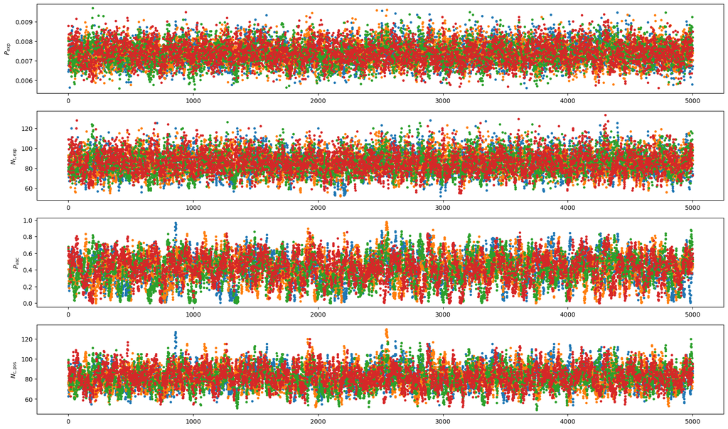

```python
# Checkpoint traces2_byI 0
fig, ax = plt.subplots(len(param_names), 1, figsize=(20, len(param_names)*3));
if chains2.__class__ == list:
    cr.plot_traces(chains2[:min(8,len(chains2))], ax, labels=param_labels);
else:
    cr.plot_traces(chains2[:min(8,chains2.shape[0]),:,:], ax, labels=param_labels);
# End checkpoint
```

Next the Gelman-Rubin convergence criterion and effective number of samples. Adjust the value of `maxlag` below if needed. Note that the test thresholds below are somewhat arbitrary, but fine for practice.

```python
maxlag = 1000 # you might need to change this
```

```python
# Checkpoint converge2 1
R = cr.GelmanRubinR(chains2)
print("R =", R)
assert np.all(R < 1.05)
neff = cr.effective_samples(chains2, maxlag=maxlag, throw=True)
print("neff =", neff)
assert np.all(neff > 500)
# End checkpoint
```

```
R = [1.0006363  1.00057578 1.00089057 1.00122743]
neff = [1819.40908417 1806.50088555  926.82733261 1125.70049109]
```

Assuming these tests were passed, we'll combine the chains and look at a triangle.

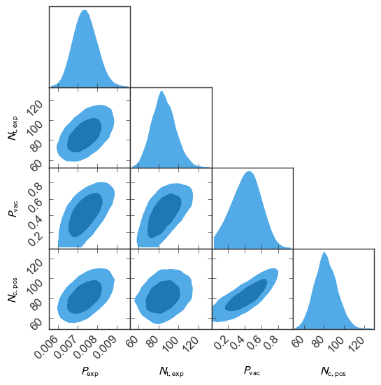

```python
# Checkpoint triangle2_byI 0
chain2 = np.concatenate(chains2, axis=0)
plotGTC(chain2, paramNames=param_labels, figureSize=6, customLabelFont={'size':12}, customTickFont={'size':12});
# End checkpoint
```

```python
# Checkpoint integer_test2 1
assert np.all(chain2[:,1] == np.round(chain2[:,1]))
assert np.all(chain2[:,3] == np.round(chain2[:,3]))
# End checkpoint
```

### Summarize results

As before, compute:

1. the posterior mode of $P_\mathrm{vac}$,
2. the 95% highest-posterior-density credible interval for $P_\mathrm{vac}$, and
3. the posterior probability that $P_\mathrm{vac} > 0.6$

Show and explain your work, and save the results in the corresponding variables named below.

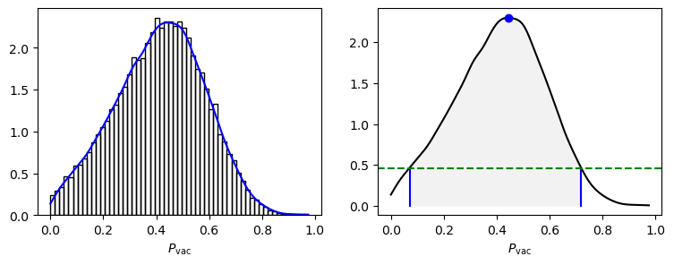

```python
# Pvac_mode = ...
# Pvac_min = ... # lower bound of the credible interval
# Pvac_max = ... # lower bound of the credible interval
# P_gt_60 = ... # probability that Pvac > 60%
# All as scalars, please

# YOUR CODE HERE
raise NotImplementedError()
```

```python
print(Pvac_mode, Pvac_min, Pvac_max, P_gt_60)
```

```
0.4426506062370321 0.0706139683020707 0.7173853542505421 0.13265
```

Is the constraint on $P_\mathrm{vac}$ compatible with the ~70% mentioned in the article from pooling the 2 types of treatment? If not, any idea why?

```python
# here we will check various aspects of your results
# Tests post_test2 (1 point)
```

# Parting thoughts

Returning to questions 2 and 3 posed at the beginning of the notebook, the answers for the Pfizer/BioNTech case are

- Yes, the information given in the reporting is enough to estimate the uncertainty in effectiveness (albeit with assumptions about the exact size of the control and treatment groups... you could free those parameters within some justifiable priors if you were so inclined, and I'm confident the answer would still be yes).
- The specific values you get will depend on what priors were chosen, but the 95% constraint on $P_\mathrm{vac}$ will be at the several percent level for any reasonable choice. So, indeed, not nailed down perfectly, but surely well enough to call the vaccine effective.

For the AstraZeneca case, the publicly reported information was not complete enough to do a proper analysis, but it was possible to get... something... by making broadly reasonable prior assumptions. Having the real data would have been much better! (They are, presumably, available in a journal somewhere, but we haven't bothered to find them.)

Beyond any historical interest, this has hopefully been good practice setting up generative models and carrying out inference, with less scaffolding given to you.

```python
# moar housekeeping
# Tests housekeeping2
```

#### Endnotes

##### Note 1

You can see a representative example of the coverage of the Moderna vaccine in this [Time article](https://time.com/5912491/moderna-covid-19-vaccine-effectiveness/):

> In a press release reporting on the DSMB’s review, the company said among the more than 30,000 people enrolled in the study, there were 95 cases of COVID-19 analyzed so far, and 90 of them occurred in the placebo group.

The information provided is comparable to that for the Pfizer/BionNTech vaccine, as are the results, as you can verify for yourself.